# Report

Author

Candidate 277353

```r
#load packages
library(lavaan)
library(semPlot)
library(semptools)
library(kableExtra)
library(tidyr)
library(tidyverse)
```

# Assignment 1 - Candidate 277353

## **Analysis plan**

The team tested the following hypothesis:

- H<sub>1</sub>: The relationship between employability and SEC will be fully mediated by a combination of interdependence and pro-sociality mediating in sequence and school quality mediating in parallel to the serial factors.

An initial analysis will be run, fitting the data to eight simple linear regressions of each of the interaction paths of the planned model. If the simple regressions between the predictor and mediators and between the mediators and outcome are significant the mediation model will be fitted. If one or more of the simple regressions between the predictor and mediators or between the mediators and outcome is non-significant the mediation model will be abandoned and the coefficients of the simple regressions will be reported.

To test this hypotheses, the data will be fitted to a SEM mediation model with 5000 non-parametric bootstrap samples. The model will use SEC as an exogenous predictor variable, interdependence and pro-sociality as serial endogenous mediating variables, school quality as a parallel endogenous mediating variable, and employability as endogenous outcome variable.

If one or more of the paths of the mediation model are non-significant, an alternative model will be considered .

## **Coding**

This section of the report includes creation of data, fitting of the planned models and creation of plots. Results and analysis will be reported under Results.

```r
# create data
set.seed(22335) #
SEC <- rnorm(250)
Dep <- 0.60*SEC + rnorm(250)
Soc <- 0.35*SEC + rnorm(250)
Sch <- 0.55*SEC + rnorm(250)
Emp <- 0.35*Soc + 0.1*Soc + 0.33*Sch + rnorm(250)

df <- data.frame(SEC=SEC, Dep=Dep, Soc=Soc, Sch=Sch, Emp=Emp)



#Check paths for significance
model_a1 <- lm(Dep~SEC, data = df)
tbl1 <- model_a1 |>
  broom::tidy(, conf.int = T) |>
  mutate(
    p.value = scales::pvalue(p.value)
  ) |>
  kable(
    col.names = c("Predictor", "B", "SE", "F", "p", "CI Low", "CI High"),
    digits = c(0, 2, 3, 2, 3, 2, 2),
     align=rep('c', 6)
  )
tbl1

model_a2 <- lm(Soc~SEC, data = df)
tbl2 <- model_a2 |>
  broom::tidy(, conf.int = T) |>
  mutate(
    p.value = scales::pvalue(p.value)
  ) |>
  kable(
    col.names = c("Predictor", "B", "SE", "F", "p", "CI Low", "CI High"),
    digits = c(0, 2, 3, 2, 3, 2, 2),
     align=rep('c', 6)
  )
tbl2

model_b4 <- lm(Soc~Dep, data = df)
tbl3 <- model_b4 |>
  broom::tidy(, conf.int = T) |>
  mutate(
    p.value = scales::pvalue(p.value)
  ) |>
  kable(
    col.names = c("Predictor", "B", "SE", "F", "p", "CI Low", "CI High"),
    digits = c(0, 2, 3, 2, 3, 2, 2),
     align=rep('c', 6)
  )
tbl3

model_a3 <- lm(Sch~SEC, data = df)
tbl4 <- model_a3 |>
  broom::tidy(, conf.int = T) |>
  mutate(
    p.value = scales::pvalue(p.value)
  ) |>
  kable(
    col.names = c("Predictor", "B", "SE", "F", "p", "CI Low", "CI High"),
    digits = c(0, 2, 3, 2, 3, 2, 2),
     align=rep('c', 6)
  )
tbl4

model_b1 <- lm(Emp~Dep, data = df)
tbl5 <- model_b1 |>
  broom::tidy(, conf.int = T) |>
  mutate(
    p.value = scales::pvalue(p.value)
  ) |>
  kable(
    col.names = c("Predictor", "B", "SE", "F", "p", "CI Low", "CI High"),
    digits = c(0, 2, 3, 2, 3, 2, 2),
     align=rep('c', 6)
  )
tbl5

model_b2 <- lm(Emp~Soc, data = df)
tbl6 <- model_b2 |>
  broom::tidy(, conf.int = T) |>
  mutate(
    p.value = scales::pvalue(p.value)
  ) |>
  kable(
    col.names = c("Predictor", "B", "SE", "F", "p", "CI Low", "CI High"),
    digits = c(0, 2, 3, 2, 3, 2, 2),
     align=rep('c', 6)
  )
tbl6

model_b3 <- lm(Emp~Sch, data = df)
tbl7 <- model_b3 |>
  broom::tidy(, conf.int = T) |>
  mutate(
    p.value = scales::pvalue(p.value)
  ) |>
  kable(
    col.names = c("Predictor", "B", "SE", "F", "p", "CI Low", "CI High"),
    digits = c(0, 2, 3, 2, 3, 2, 2),
     align=rep('c', 6)
  )
tbl7

model_c <- lm(Emp~SEC, data = df)
tbl8 <- model_c |>
  broom::tidy(, conf.int = T) |>
  mutate(
    p.value = scales::pvalue(p.value)
  ) |>
  kable(
    col.names = c("Predictor", "B", "SE", "F", "p", "CI Low", "CI High"),
    digits = c(0, 2, 3, 2, 3, 2, 2),
     align=rep('c', 6)
  )
tbl8

#parallel and serial mediation model
model <- ' # direct effect
             Emp ~ c*SEC
           # mediator
             Dep ~ a1*SEC
             Soc ~ a2*SEC
             Soc ~ b4*Dep
             Sch ~ a3*SEC
             Emp ~ b1*Dep
             Emp ~ b2*Soc
             Emp ~ b3*Sch
           # moderator

           # indirect effect (a*b)
             a1b4b2 := a1*b4*b2
             a1b1 := a1*b1
             a2b2 := a2*b2
             a3b3 := a3*b3
           # total effect
             total := c + (a1*b4*b2) + (a1*b1) + (a2*b2) + (a3*b3)
         '



#Fit model
model_fit <- sem(model, data = df, se = 'bootstrap', bootstrap = 5000)

#Results table
tbl9 <- model_fit |>
  parameterEstimates() |>
  kable(
   #col.names = c("Outcome", "Function", "Predictor", "B", "SE", "z", "p", "CI Low", "CI High"),
    digits = c(1, 1, 1, 1, 2, 2, 2, 3, 2, 2),
     align=rep('c', 10)
  )

#Diagram
plot <- semPaths(model_fit,
         whatLabels = "est",
         sizeMan = 10,
         style = "ram",
         layout = "tree",
         intercepts = FALSE,
         rotation = 2, edge.label.ceSEC = 1)
```

```r
plot_sig <- mark_sig(plot,model_fit)
list <- c("Emp ~ Soc" = .2)
plot_edge <- set_edge_label_position(plot_sig, position_list = list)
plot(plot_edge)
```

```r
#second model
#parallel mediation model
model2 <- ' # direct effect
             Emp ~ c*SEC
           # mediator
             Soc ~ a2*SEC
             Sch ~ a3*SEC
             Emp ~ b2*Soc
             Emp ~ b3*Sch
           # moderator

           # indirect effect (a*b)
             a2b2 := a2*b2
             a3b3 := a3*b3
           # total effect
             total := c + (a2*b2) + (a3*b3)
         '



#Fit model
model_fit2 <- sem(model2, data = df, se = 'bootstrap', bootstrap = 5000)

#Results table
tbl10 <- model_fit2 |>
  parameterEstimates() |>
  kable(
   #col.names = c("Outcome", "Function", "Predictor", "B", "SE", "z", "p", "CI Low", "CI High"),
    digits = c(1, 1, 1, 1, 2, 2, 2, 3, 2, 2),
     align=rep('c', 10)
  )

#Diagram
plot2 <- semPaths(model_fit2,
         whatLabels = "est",
         sizeMan = 10,
         style = "ram",
         layout = "tree",
         intercepts = FALSE,
         rotation = 2, edge.label.ceSEC = 1)
```

```r
plot_sig2 <- mark_sig(plot2,model_fit2)
list2 <- c("Emp ~ Sch" = .2)
plot_edge2 <- set_edge_label_position(plot_sig2, position_list = list2)
plot(plot_edge2)
```

## **Results**

### Initial analyses

Table 1 to Table 8 show the simple regressions of each interaction path from the mediation model. Seven of the eight interaction paths were significant when regressed individually. Path b4 (interdependence -> pro-sociality) was non significant when regressed individually (Table 3 b = 0.10, p = .093 , F = 1.69, se = 0.06, ci[0.95] = (-0.02; 0.22)). This could indicate that there is not enough justification for the mediation model but as the other paths were significant the decision was made to fit the model.

Table 1: Output of simple regression between SEC and interdependence

| Predictor | B | SE | F | p | CI Low | CI High |
| --- | --- | --- | --- | --- | --- | --- |
| (Intercept) | -0.06 | 0.061 | -0.94 | 0.348 | -0.18 | 0.06 |
| SEC | 0.61 | 0.059 | 10.24 | <0.001 | 0.49 | 0.72 |

Table 2: Output of simple regression between SEC and pro-sociality

| Predictor | B | SE | F | p | CI Low | CI High |
| --- | --- | --- | --- | --- | --- | --- |
| (Intercept) | -0.02 | 0.067 | -0.30 | 0.761 | -0.15 | 0.11 |
| SEC | 0.22 | 0.064 | 3.41 | <0.001 | 0.09 | 0.35 |

Table 3: Output of simple regression between interdependence and pro-sociality

| Predictor | B | SE | F | p | CI Low | CI High |
| --- | --- | --- | --- | --- | --- | --- |
| (Intercept) | 0.0 | 0.068 | -0.05 | 0.963 | -0.14 | 0.13 |
| Dep | 0.1 | 0.059 | 1.69 | 0.093 | -0.02 | 0.22 |

Table 4: Output of simple regression between SEC and school quality

| Predictor | B | SE | F | p | CI Low | CI High |
| --- | --- | --- | --- | --- | --- | --- |
| (Intercept) | -0.01 | 0.067 | -0.10 | 0.923 | -0.14 | 0.12 |
| SEC | 0.55 | 0.064 | 8.57 | <0.001 | 0.42 | 0.68 |

Table 5: Output of simple regression between interdependence and employabiliy

| Predictor | B | SE | F | p | CI Low | CI High |
| --- | --- | --- | --- | --- | --- | --- |
| (Intercept) | -0.03 | 0.079 | -0.34 | 0.736 | -0.18 | 0.13 |
| Dep | 0.19 | 0.069 | 2.69 | 0.008 | 0.05 | 0.32 |

Table 6: Output of simple regression between pro-sociality and employability

| Predictor | B | SE | F | p | CI Low | CI High |
| --- | --- | --- | --- | --- | --- | --- |
| (Intercept) | -0.03 | 0.070 | -0.38 | 0.703 | -0.17 | 0.11 |
| Soc | 0.58 | 0.066 | 8.78 | <0.001 | 0.45 | 0.71 |

Table 7: Output of simple regression between school quality and employability

| Predictor | B | SE | F | p | CI Low | CI High |
| --- | --- | --- | --- | --- | --- | --- |
| (Intercept) | -0.04 | 0.075 | -0.56 | 0.573 | -0.19 | 0.11 |
| Sch | 0.39 | 0.063 | 6.18 | <0.001 | 0.26 | 0.51 |

Table 8: Output of simple regression between SEC and employability

| Predictor | B | SE | F | p | CI Low | CI High |
| --- | --- | --- | --- | --- | --- | --- |
| (Intercept) | -0.06 | 0.077 | -0.72 | 0.474 | -0.21 | 0.10 |
| SEC | 0.36 | 0.075 | 4.82 | <0.001 | 0.21 | 0.51 |

### Mediation model

Table 9 shows the unstandardised output of the fitted mediation model. The total effect was significant (b = 0.36, p < .001, z = 4.66, se = 0.08, ci[0.95] = (0.21; 0.52)). However, the indirect sequential path of interdependence and pro-sociality was non-significant (b = 0.00, p = .864, z = -0.17, se = 0.02, ci[0.95] = (-0.04; 0.04)) and the indirect path of interdependence was also non-significant (b = -0.01, p = .900, z = -0.13, se = 0.04, ci[0.95] = (-0.09; 0.08)), but the indirect path of pro-sociality was significant (b = 0.12, p = .006, z = 2.73, se = 0.04, ci[0.95] = (0.04; 0.21)). The parallel path of school quality was significant (b = 0.16, p < .001, z = 4.24, se = 0.04, ci[0.95] = (0.09; 0.24)). Despite initial analysis finding that employability is significantly predicted by SEC, the direct path in the model was non-significant (b = 0.09, p = .242 , z = 1.17, se = 0.08, ci[0.95] = (-0.06; 0.24)) suggesting that the fitted model represents a full mediation.

Table 9: Output of fitted mediation model

| lhs | op | rhs | label | est | se | z | pvalue | ci.lower | ci.upper |
| --- | --- | --- | --- | --- | --- | --- | --- | --- | --- |
| Emp | ~ | SEC | c | 0.09 | 0.08 | 1.17 | 0.242 | -0.06 | 0.24 |
| Dep | ~ | SEC | a1 | 0.61 | 0.06 | 9.89 | 0.000 | 0.49 | 0.73 |
| Soc | ~ | SEC | a2 | 0.23 | 0.08 | 2.85 | 0.004 | 0.07 | 0.38 |
| Soc | ~ | Dep | b4 | -0.01 | 0.07 | -0.18 | 0.861 | -0.14 | 0.12 |
| Sch | ~ | SEC | a3 | 0.55 | 0.06 | 9.04 | 0.000 | 0.43 | 0.67 |
| Emp | ~ | Dep | b1 | -0.01 | 0.07 | -0.13 | 0.900 | -0.15 | 0.14 |
| Emp | ~ | Soc | b2 | 0.52 | 0.06 | 8.25 | 0.000 | 0.40 | 0.64 |
| Emp | ~ | Sch | b3 | 0.29 | 0.06 | 4.91 | 0.000 | 0.18 | 0.41 |
| Emp | ~~ | Emp |  | 1.07 | 0.09 | 11.62 | 0.000 | 0.87 | 1.24 |
| Dep | ~~ | Dep |  | 0.93 | 0.08 | 10.99 | 0.000 | 0.76 | 1.09 |
| Soc | ~~ | Soc |  | 1.09 | 0.09 | 12.61 | 0.000 | 0.92 | 1.25 |
| Sch | ~~ | Sch |  | 1.10 | 0.10 | 11.19 | 0.000 | 0.90 | 1.29 |
| SEC | ~~ | SEC |  | 1.07 | 0.00 | NA | NA | 1.07 | 1.07 |
| a1b4b2 | := | a1*b4*b2 | a1b4b2 | 0.00 | 0.02 | -0.17 | 0.864 | -0.04 | 0.04 |
| a1b1 | := | a1*b1 | a1b1 | -0.01 | 0.04 | -0.13 | 0.900 | -0.09 | 0.08 |
| a2b2 | := | a2*b2 | a2b2 | 0.12 | 0.04 | 2.73 | 0.006 | 0.04 | 0.21 |
| a3b3 | := | a3*b3 | a3b3 | 0.16 | 0.04 | 4.24 | 0.000 | 0.09 | 0.24 |
| total | := | c+(a1*b4*b2)+(a1*b1)+(a2*b2)+(a3*b3) | total | 0.36 | 0.08 | 4.66 | 0.000 | 0.21 | 0.52 |

Figure 1 shows the unstandardised coefficients of the model plotted in a mediation diagram.

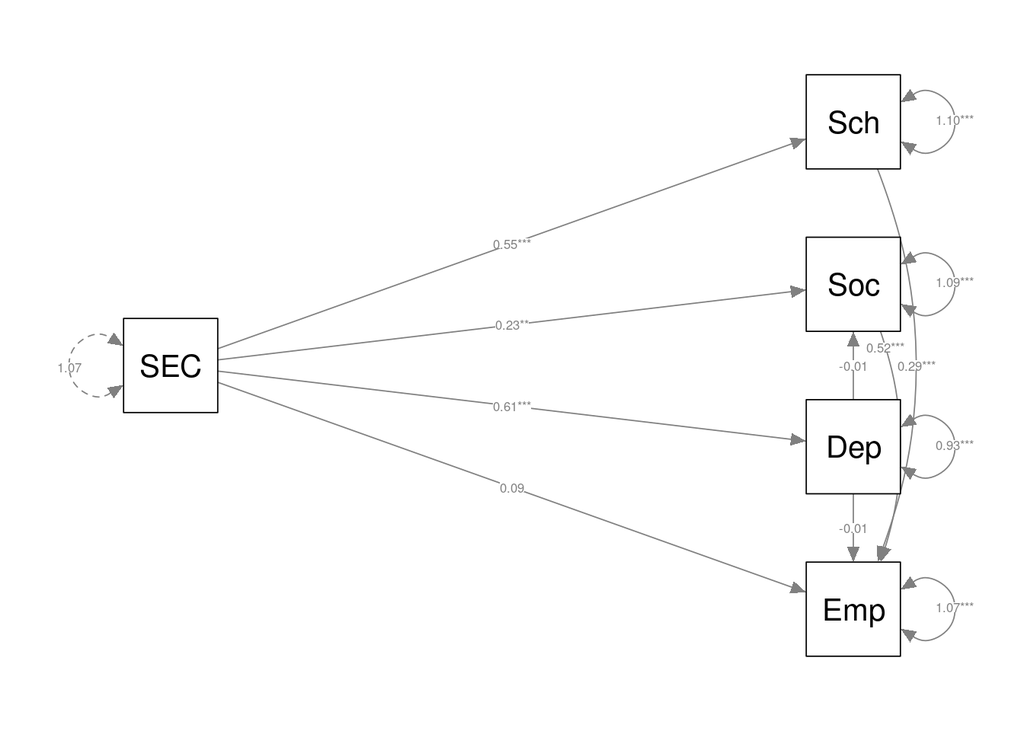

Figure 1: Regression coefficients for the relationship between SEC and employability, mediated by interdependence pro-sociality in series and school quality in paralell. * indicates P ≤ 0.05, ** indicates P ≤ 0.01, *** indicates P ≤ 0.001. Single sided arrows indicate relationship paths. Double sided arrows indicate variable variance

The model did not find interdependence to be correlated with either pro-sociality or employability. As a result, we theorise that interdependence is predicted by SEC but that interdependence is not a factor in the disparity in employability between individuals. The decision was made to adjust the model, removing interdependence as a variable. The remaining path labels were kept the same to help interpretation.

Table 10 shows the unstandardised output of the adjusted mediation model. The total effect was significant (b = 0.36, p < .001, z = 4.76, se = 0.08, ci[0.95] = (0.21; 0.51)). Both mediating paths, through pro-sociality and through school quality, were significant (b = 0.11, p = .003, z = 2.95, se = 0.04, ci[0.95] = (0.04; 0.19), and b = 0.16, p = < .001, z = 4.26, se = 0.04, ci[0.95] = (0.09; 0.24)). The direct effect was non-significant (b = 0.08, p = .221, z = 1.22, se = 0.07, ci[0.95] = (-0.05; 0.22)) suggesting that the adjusted model represents a full mediation.

Table 10: Output of fitted adjusted mediation model

| lhs | op | rhs | label | est | se | z | pvalue | ci.lower | ci.upper |
| --- | --- | --- | --- | --- | --- | --- | --- | --- | --- |
| Emp | ~ | SEC | c | 0.08 | 0.07 | 1.22 | 0.221 | -0.05 | 0.22 |
| Soc | ~ | SEC | a2 | 0.22 | 0.07 | 3.09 | 0.002 | 0.08 | 0.36 |
| Sch | ~ | SEC | a3 | 0.55 | 0.06 | 8.90 | 0.000 | 0.43 | 0.67 |
| Emp | ~ | Soc | b2 | 0.52 | 0.06 | 8.19 | 0.000 | 0.40 | 0.64 |
| Emp | ~ | Sch | b3 | 0.29 | 0.06 | 4.94 | 0.000 | 0.18 | 0.41 |
| Emp | ~~ | Emp |  | 1.07 | 0.09 | 11.78 | 0.000 | 0.88 | 1.23 |
| Soc | ~~ | Soc |  | 1.09 | 0.09 | 12.63 | 0.000 | 0.92 | 1.26 |
| Sch | ~~ | Sch |  | 1.10 | 0.10 | 11.27 | 0.000 | 0.90 | 1.28 |
| SEC | ~~ | SEC |  | 1.07 | 0.00 | NA | NA | 1.07 | 1.07 |
| a2b2 | := | a2*b2 | a2b2 | 0.11 | 0.04 | 2.95 | 0.003 | 0.04 | 0.19 |
| a3b3 | := | a3*b3 | a3b3 | 0.16 | 0.04 | 4.26 | 0.000 | 0.09 | 0.24 |
| total | := | c+(a2*b2)+(a3*b3) | total | 0.36 | 0.08 | 4.76 | 0.000 | 0.21 | 0.51 |

Figure 2 shows the unstandardised coefficients of the adjusted model plotted in a mediation diagram.

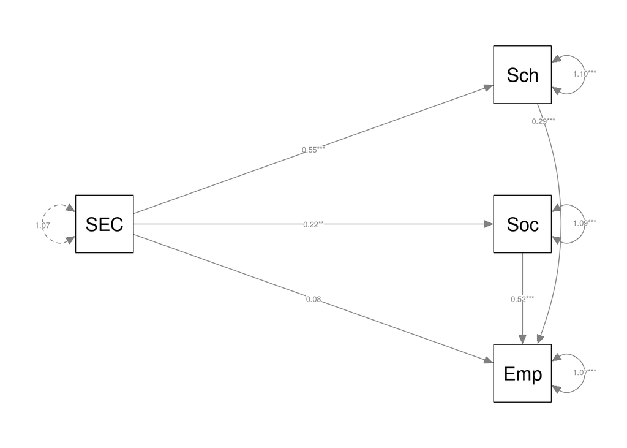

Figure 2: Regression coefficients for the relationship between SEC and employability, mediated by pro-sociality and school quality. * indicates P ≤ 0.05, ** indicates P ≤ 0.01, *** indicates P ≤ 0.001. Single sided arrows indicate relationship paths. Double sided arrows indicate variable variance

## Summary

The adjusted model allowed for modelling with no non-significant mediating pathways but the resulting coefficients were not meaningfully different from the original model.